# DImodelsVis with regression models fit using the DImodelsMulti R package

### Loading necessary packages

```r
library(DImodels)
library(DImodelsVis)
library(DImodelsMulti)
library(dplyr)
library(ggplot2)
```

### Data exploration

#### Load data

This data (henceforward referred as `Belgium`) comes from a BEF experiment conducted in Belgium as part of the wider “Agrodiversity Experiment” [Kirwan et al 2014](https://doi.org/10.6084/m9.figshare.c.3307098.v1). In this study, thirty experimental plots were established with one to four species (two grasses G1-G2 and legumes L1-L2), representing fifteen plant communities, each sown at two seeding densities. Three ecosystem function responses, namely DM yield (called `Sown`), Weed suppression (called `Weed`) and Nitrogen yield (called `N`) are recorded for each plot at a single time point and stored in the column `Y`. The data is available in the [`DImodelsMulti`](https://cran.r-project.org/package=DImodelsMulti) R package and an analysis of the this dataset can be found in [Dooley et al., 2015](https://doi.org/10.1111/ele.12504).

```r
head(dataBEL)
```

```
#>   Plot  G1  G2  L1  L2 Density  Var VarNum       Y
#> 1    1 0.7 0.1 0.1 0.1       1 Sown      1 104.156
#> 2    1 0.7 0.1 0.1 0.1       1 Weed      2 100.058
#> 3    1 0.7 0.1 0.1 0.1       1    N      3  87.996
#> 4    2 0.1 0.7 0.1 0.1       1 Sown      1  82.547
#> 5    2 0.1 0.7 0.1 0.1       1 Weed      2  89.801
#> 6    2 0.1 0.7 0.1 0.1       1    N      3  72.239
```

### Model fitting

We fit the average pairwise Diversity-Interactions model to all three ecosystem functions in the `Belgium` dataset using the `DImulti()` function from the `DImodelsMulti` package. The main benefit of fitting a single model for all responses is that it allows us to capture covariances between the ecosystem functions.

```r
# Name of compositional predictors (species)
species <- c("G1", "G2", "L1", "L2")
# Functional groupings of species
FG <- c("Gr", "Gr", "Le", "Le")
# Colours to be used for pie-glyphs for all figures
pie_cols <- get_colours(vars = species, FG = FG)

model <- DImulti(prop = species, FG = FG, y = "Y",
                 eco_func = c("Var", "un"),
                 unit_IDs = "Plot", DImodel = "AV",
                 method = "REML", data = dataBEL)
```

The model coefficients are as follows

```r
model
```

```
#> Note:
#> Method Used = REML
#> Correlation Structure Used = un
#>  Average Term Model
#> Theta value(s) = 1,1,1
#>
#> Generalized least squares fit by REML
#>   Model: Y ~ 0 + Var:((G1_ID + G2_ID + L1_ID + L2_ID + AV))
#>       AIC       BIC    logLik
#>  560.2461  608.9134 -259.1231
#>
#>  Multivariate Correlation Structure: General
#>  Formula: ~0 | Plot
#>  Parameter estimate(s):
#>  Correlation:
#>   1      2
#> 2  0.738
#> 3 -0.175  0.386
#>
#>
#> Table: Fixed Effect Coefficients
#>
#>                 Beta      Std. Error   t-value   p-value     Signif
#> --------------  --------  -----------  --------  ----------  -------
#> VarN:G1_ID      +49.113   4.966        9.889     3.091e-15   ***
#> VarSown:G1_ID   +67.548   4.176        16.174    3.662e-26   ***
#> VarWeed:G1_ID   +75.241   8.341        9.020     1.362e-13   ***
#> VarN:G2_ID      +33.173   4.966        6.679     3.682e-09   ***
#> VarSown:G2_ID   +49.019   4.176        11.737    1.182e-18   ***
#> VarWeed:G2_ID   +86.523   8.341        10.373    3.826e-16   ***
#> VarN:L1_ID      +93.338   4.966        18.794    4.283e-30   ***
#> VarSown:L1_ID   +76.145   4.176        18.233    2.777e-29   ***
#> VarWeed:L1_ID   +54.803   8.341        6.570     5.871e-09   ***
#> VarN:L2_ID      +72.159   4.966        14.529    1.669e-23   ***
#> VarSown:L2_ID   +50.810   4.176        12.166    1.999e-19   ***
#> VarWeed:L2_ID   +38.722   8.341        4.642     1.437e-05   ***
#> VarN:AV         +67.685   10.827       6.251     2.263e-08   ***
#> VarSown:AV      +86.495   9.104        9.500     1.674e-14   ***
#> VarWeed:AV      +83.296   18.184       4.581     1.809e-05   ***
#>
#> Signif codes: 0-0.001 '***', 0.001-0.01 '**', 0.01-0.05 '*', 0.05-0.1 '+', 0.1-1.0 ' '
#>
#> Degrees of freedom: 90 total; 75 residual
#> Residual standard error: 8.271401
#>
#> Marginal variance covariance matrix
#>            N   Sown    Weed
#> N     68.416 42.450 -20.059
#> Sown  42.450 48.377  37.290
#> Weed -20.059 37.290 192.990
#>   Standard Deviations: 8.2714 6.9554 13.892
```

The average interaction effect is significant for all three ecosystem functions. Additionally, sown is positively correlated with the other two ecosystem functions while Weed and N are negatively correlated.

### Model diagnostics

The model diagnostics function works directly with `DImodelsMulti` model object. However, only the `"Pearson Residual vs Fitted"` and `"Qunatile-Quantile"` plots can be created for these models.

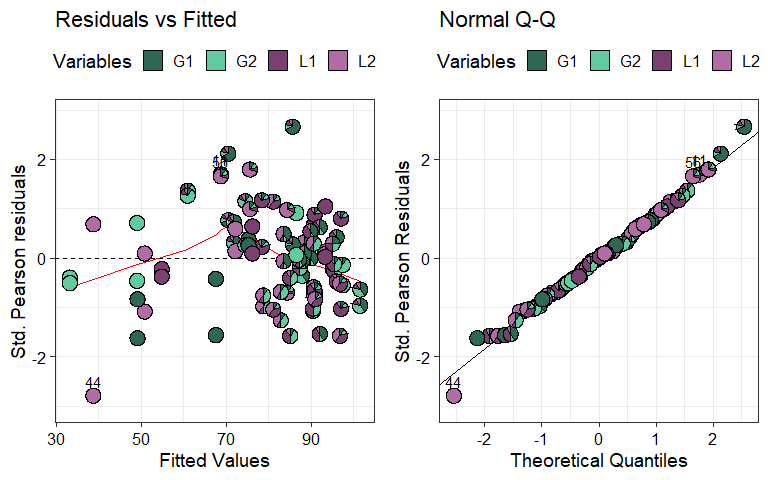

```r
model_diagnostics(model = model, which = c(1, 2), nrow = 1)
```

By default, all ecosystem functions are plotted in the same panel, however it is also possible to view them in separate panels as follows:

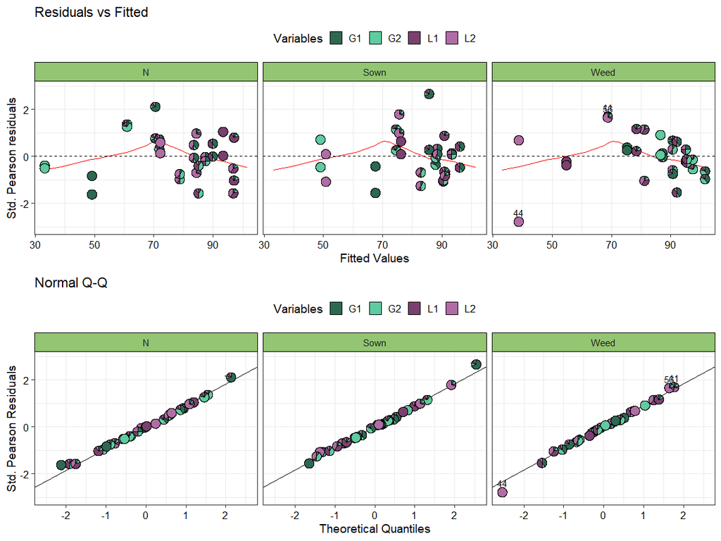

```r
model_diagnostics(model = model, which = c(1, 2), nrow = 2) +
  facet_wrap(~Var)
```

### Model interpretation

All the visualisation functions aiding with model interpretation in `DImodelsVis` integrate smoothly with statistical model objects fit using `DImodelsMulti`. The visualisations are automatically split into separate panels for each ecosystem function (or time-point) in the model by default. However, users also have the option to create the visualisations for only specific ecosystem functions (or time-points) if they desire.

#### Gradient-change plot

We depict the average BEF relationship with respect to species richness for all three ecosystem functions.

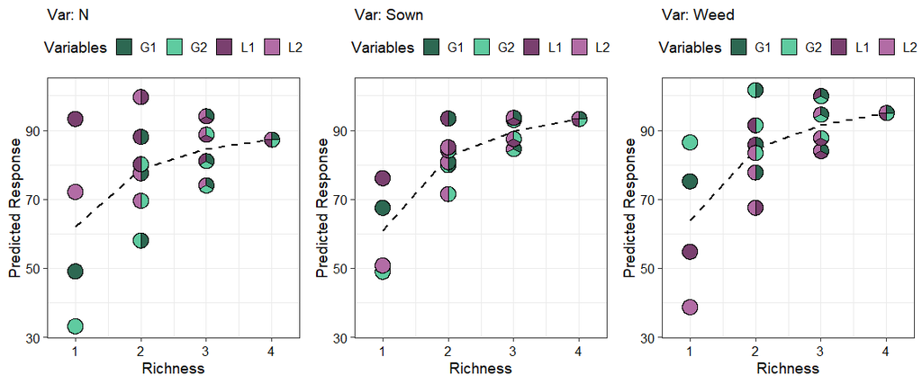

```r
grad_data <- get_equi_comms(4, variables = c("G1", "G2", "L1", "L2")) %>%
  mutate("Rich." = Richness)

gradient_change(model = model, data = grad_data, nrow = 1)
```

The BEF relationship observed across all three ecosystem functions exhibits the characteristic saturating shape, where gains in function diminish as diversity increases.

#### Conditional ternary plot

We create conditional ternary diagram with the proportion of L1 fixed to be 0, 0.25, and 0.5.

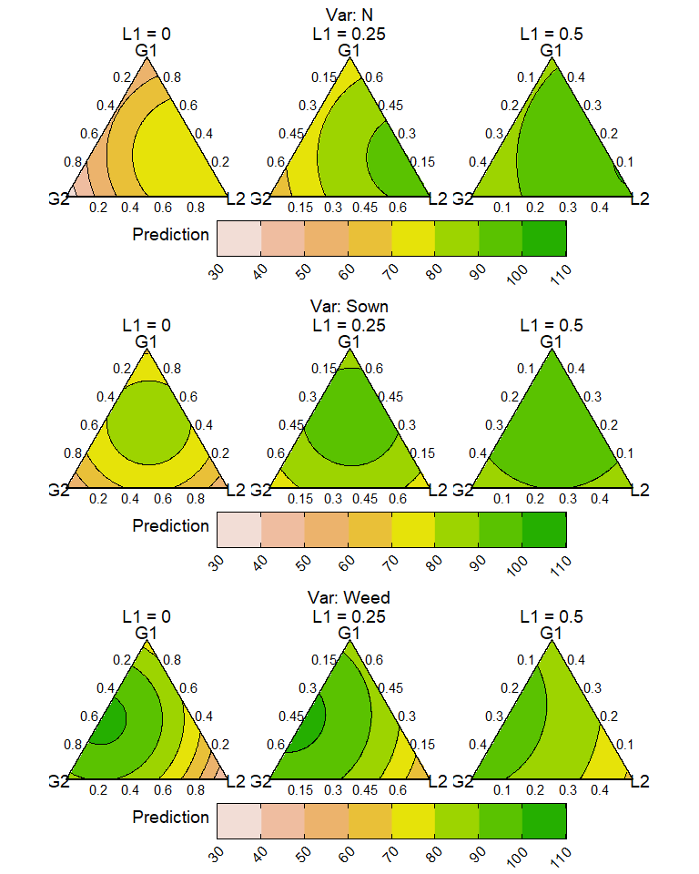

```r
conditional_ternary(model = model, resolution = 1,
                    tern_vars = c("G1", "G2", "L2"),
                    conditional = data.frame(L1 = c(0, 0.25, 0.5)),
                    lower_lim = 30, upper_lim = 110, nlevels = 8,
                    nrow = 3)
```

The prediction for DM and nitrogen yield proportion of L1 increases to 0.5, while that of weed suppression decreases.

#### Grouped ternary plot

We create a grouped ternary plot where the two grasses are grouped together and the total grasses proportion is split equally between G1 and G2. Additionally, till now we have been using the default option of showing the visualisations for each ecosystem function. As an example, to showcase how this can be changed, we will only show the plots for nitrogen yield and weed suppression in this example. However, note that this would be possible to do with any visualisation in the package.

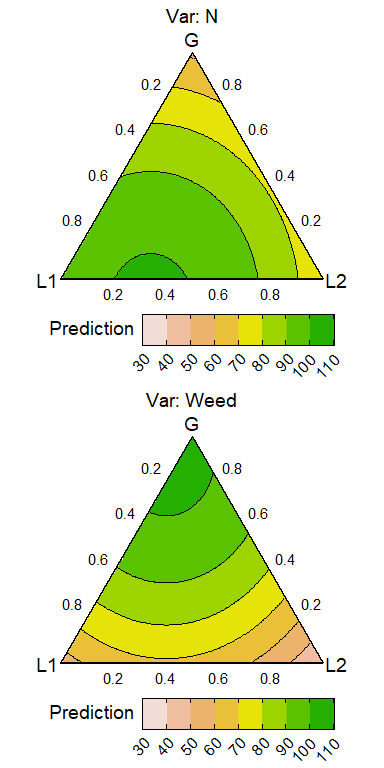

```r
grouped_ternary(model = model, resolution = 1,
                FG = c("G", "G", "L1", "L2"),
                # Split of species within each group
                values = c(0.5, 0.5, 1, 1),
                lower_lim = 30, upper_lim = 110, nlevels = 8,
                add_var = list("Var" = c("N", "Weed")),
                nrow = 2) # Arrange in two rows
```

The visualisation very clearly shows the trade-off between weed suppression and nitrogen yield as weed suppression is maximised by increasing the proportion of grasses while nitrogen yield is maximised by increases the proportion of legumes.

#### Effects plot

We visualise the effect of adding L1 and L2 to several equi-proportional mixtures on each ecosystem function.

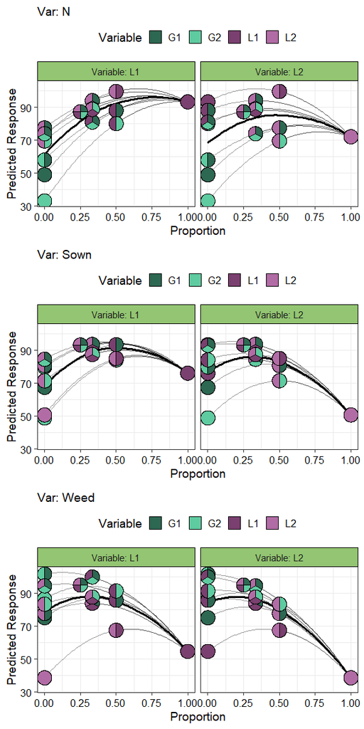

```r
eff_data <- get_equi_comms(4, variables = c("G1", "G2", "L1", "L2"))
visualise_effects(model = model, data = eff_data,
                  var_interest = c("L1", "L2"),
                  # arrange plot in three row (one for each function)
                  nrow = 3)
```

This figure shows that no single species maximizes all three ecosystem functions. For example, increasing the proportion of L1 improves dry matter and nitrogen yield but leads to a marked reduction in weed suppression.

#### Simplex path plot

We depict the change in the predicted response as we move from the four-species centroid community towards each binary two-species mixture.

In addition to the standard arguments, we also show how one can create multiple plots for different levels of any non-compositional experimental treatments in the data (if used as predictors in the model). For example, suppose we had used Density as a predictor in the model and wished to visualise how does performance differ across the two seeding density levels, one could do it as follows:

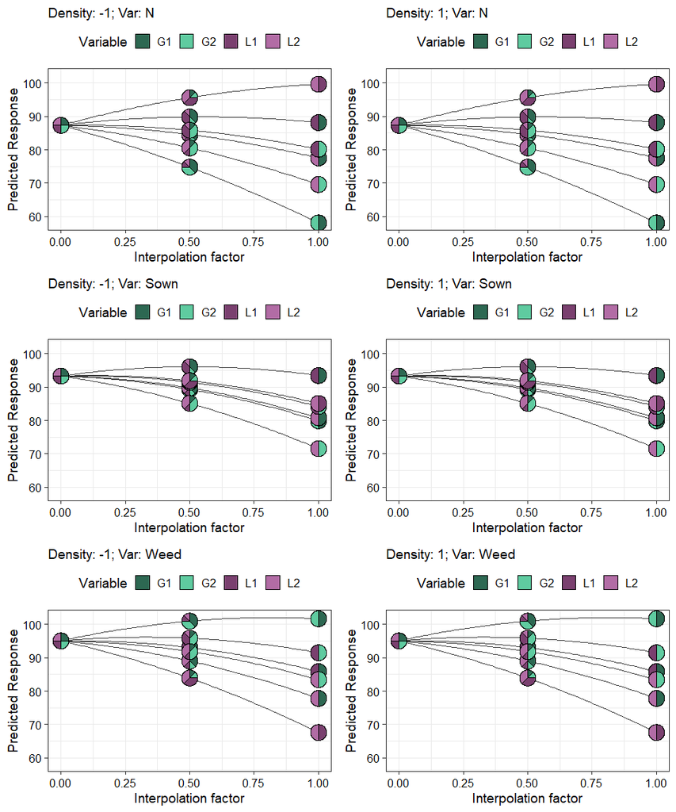

```r
# The centroid community (starting point for the straight line)
starts <- tribble( ~G1,  ~G2,  ~L1,  ~L2,
                  0.25, 0.25, 0.25, 0.25)
# The six binary mixtures (ending points for the straight lines)
ends <- tribble(~G1,    ~G2,  ~L1,  ~L2,
                  0.5,  0.5,    0,    0,
                  0.5,    0,  0.5,    0,
                  0.5,    0,    0,  0.5,
                    0,  0.5,  0.5,    0,
                    0,  0.5,    0,  0.5,
                    0,    0,  0.5,  0.5)

# Create the visualisation
simplex_path(model = model,
             starts = starts, ends = ends,
             # Manually specify to create plot for Weed and N
             add_var = list("Density" = factor(c(- 1, 1))),                nrow = 3, ncol = 2)
```

In this example, density was not included as a predictor in the model, so the two panels at different density levels appear identical. Nonetheless, the same approach could be applied in other situations when any other non-compositional variable is used as a predictor to visualise performance, across its different values. Importantly, this flexibility extends to any visualisation within the package. Furthermore, note that this would be possible to do with any visualisation in the package as well.

#### Prediction contributions plot

Currently, the prediction contributions plot does not work directly with a `DImulti` object. However, this functionality will soon be added. For the time being, here is how the prediction contributions plot can be created for a `DImulti` model.

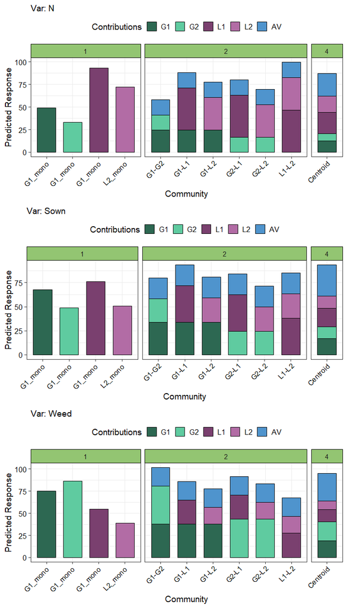

```r
pred_data <- get_equi_comms(4, richness_lvl = c(1, 2, 4),
                            variables = c("G1", "G2", "L1", "L2")) %>%
  mutate(labels = c("G1_mono", "G1_mono", "G1_mono", "L2_mono",
                    "G1-G2", "G1-L1", "G1-L2", "G2-L1", "G2-L2", "L1-L2",
                    "Centroid")) %>%
  # Repeat each community across the three ecosystem functions
  add_add_var(add_var = list("Var" = c("N", "Sown", "Weed"))) %>%
  mutate(G1_ID = G1, G2_ID = G2, L1_ID = L1, L2_ID = L2,
         AV = DI_data_E_AV(prop = 1:4, data = .)$AV,
         "Rich." = Richness)

prediction_contributions_data(data = pred_data, model = model,
                              bar_labs = "labels",
                              # Important to group the coefficients
                              groups = list("G1" = 1:3, "G2" = 4:6,
                                            "L1" = 7:9, "L2" = 10:12,
                                            "AV" = 13:15)) %>%
  prediction_contributions_plot(colours = c(pie_cols, "steelblue3"),
                                nrow = 3) +
  facet_grid(~ Rich., scale = "free_x", space = "free_x") +
  theme(axis.text.x = element_text(angle = 45, hjust = 1.1, vjust = 1.1))
```

The best performing monoculture differs across the three ecosystem function. However, the four species centroid mixture containing 25% of each species performs comparably or out-performs the best monoculture for each ecosystem function.